# Projet_IF36

# 17. Qui est le Némésis de qui ?

Le Némésis d’un joueur représente l’ennemi qui l’a tué le plus de fois en tournoi, c’est-à-dire en quelque sorte son pire ennemi.

Ici, on souhaite voir avec quels joueurs cette dynamique a été la plus puissante à travers les années. On utilisera le dataset VCT avec les joueurs pros, qui contient des couples joueur/ennemi et le nombre de fois que le joueur a tué l’ennemi, pour chaque année.

Nous allons garder le top 25 des joueurs qui ont tué le plus de fois un ennemi spécifique, toutes années confondues de 2021 à 2026. Cela nous permettra de voir les némésis significatifs de l’histoire de la compétition.

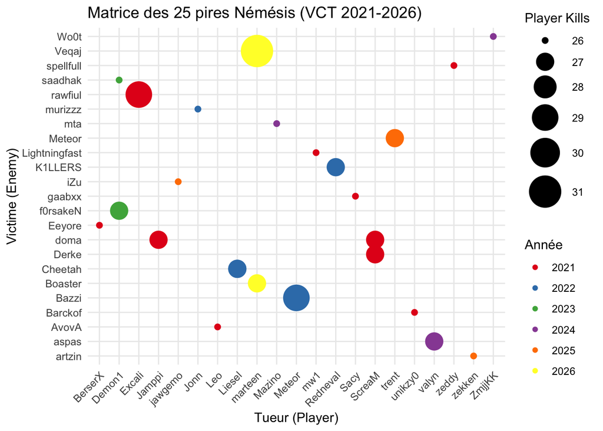

Tout d’abord, on remarque que le grand gagnant est marteen, qui a tué Veqaj bien 31 fois lors d’un même tournoi, et détient donc le record absolu. De plus, marteen a aussi tué Boaster 27 fois cette même année. On peut remarquer aussi que le seul joueur apparaissant à la fois en tant que tueur et victime est Meteor. Il a tué Bazzi 30 fois en 2022, et il a aussi été tué par trent 27 fois en 2025.

L’année 2021 semble avoir été très dure pour doma qui a été tué 27 fois par deux joueurs différents, Jamppi et ScreaM. ScreaM a d’ailleurs été très fort cette année là car il a aussi tué Derke 27 fois.

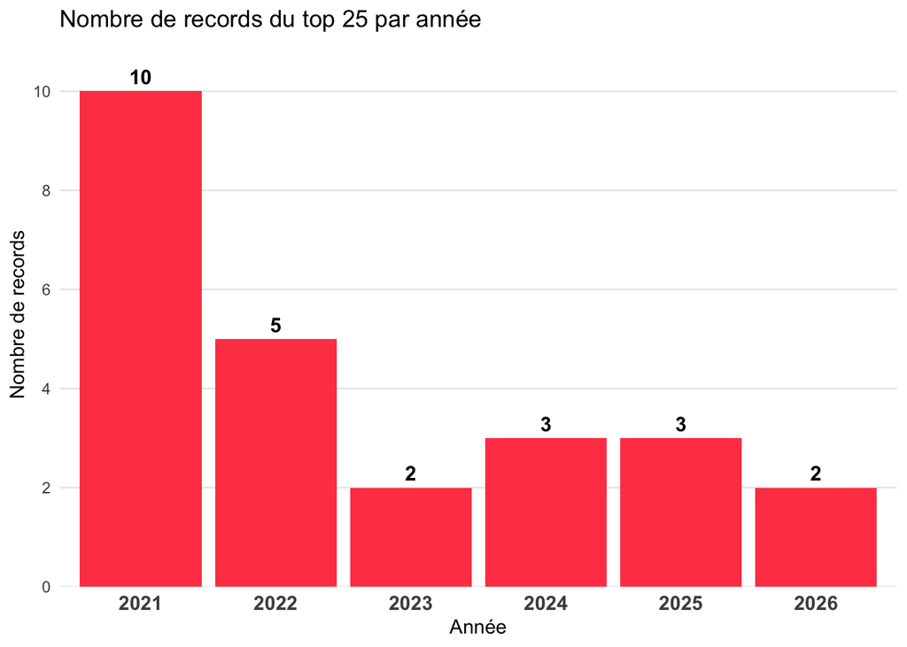

## Interprétation

L’année 2021 comporte en fait le plus de records de némésis de 2021 à 2026. Cela peut peut-être s’expliquer par le fait qu’avec le temps les joueurs ont progressé, à tel point que le niveau est assez équilibré pour que l’on évite de trop gros écarts de skill entre deux joueurs qui amènerait à de tels récords de kills par un même joueur sur un seul ennemi.

Mais on retient que marteen est le seul responsable des deux records de 2026, qui incluent le plus gros nombre de kills. On peut donc se dire qu’il a totalement dominé la compétition cette année sur ce plan-là, et qu’il a été extrêmement bon pour contrer les joueurs Veqaj et Boaster.

# Conclusion

Au cours de ce rapport, nous avons pu étudier les facettes les plus importantes de la scène compétitive de Valorant, et ainsi extraire les points qui permettent de faire pencher la balance en sa faveur. Nous avons vu que le choix de la carte, des agents et des joueurs était essentiels. Nous avons vu que les changements de joueurs étaient risqués, mais nécessaires pour trouver une équipe fonctionnelle. Malgré tout, même les meilleurs joueurs ne restent pas au sommet bien longtemps, notamment à cause des changements de méta qui favorisent certains styles de jeu.

Valorant est un jeu qui change très rapidement, et sur ce projet, nous avons souvent utilisé les données des 5 dernières années pour être plus exhaustif, mais il aurait été pertinent selon nous de rajouter des graphes qui prennent en compte ces écarts de temps. De plus, Il s’agit d’un jeu très complexe à prendre en main, et les informations que nous avons récupéré ne permettent pas de présenter correctement cette complexité. Par exemple, nous avons beaucoup vu le nom des agents comme Chamber et Jett, mais nous n’avons pas pu expliquer ce qu’ils peuvent faire, ni même à quoi ils ressemblent. Plus d’images auraient été nécessaires pour rendre le rapport plus compréhensible.

Enfin, nous avons choisi tout compte fait d’écarter certaines de nos questions qui étaient quelques fois trop amibitieuses comme la question “Qu’est-ce qui compte le plus pour gagner une partie ?”: tout le monde aimerait pouvoir répondre simplement à cette question mais cela risque d’être impossible. De plus, certaines de nos questions nous ont finalement semblé peu pertinentes ou alors nos données n’étaient pas adaptées pour y répondre, comme les questions 14, 15 ou 20. Nous aurions aimé avoir eu plus de temps pour répondre à certaines, et nous aurions aimé trouver des questions plus pertinentes à la base même si cela était compliqué avec une connaissance limitée des données.

### Mots de la fin :

Elio : J’ai beaucoup aimé découvrir la visualisation et la manipulation de données avec R et Tidyverse, qui ont été des outils très efficaces et largement satisfaisants pour mettre en pratique les parties théoriques du cours. L’analyse exploratoire s’est avérée être une démarche très intéressante et engageante. J’aurais aimé pouvoir davantage faire le lien en détail avec les compétences des agents et leur style de jeu, afin de mieux comprendre certaines dynamiques.

Morgane : J’ai beaucoup aimé travailler sur ce sujet même si ma méconnaissance du jeu m’a un peu ralentie. Les autres membres du groupe m’ont beaucoup soutenue et m’ont aidé à comprendre le vocabulaire propre au jeu. Je suis fière d’avoir pu réaliser ce projet qui a été très instructif sur bien des niveaux.

Louis : J’ai beaucoup aimé utiliser R de façon à la fois créative et technique. Utiliser mes compétences pour travailler sur un jeu que j’apprécie m’a motivé pour produire un rapport dont je suis plutôt fier. Les autres membres du groupe m’ont également bien aidé. Je considère ce projet comme une réussite sur tous les niveaux, mais j’aurais aimé avoir plus de temps pour peaufiner quelques détails.

Ilias : J’ai trouvé l’utilisation de R très pertinente pour analyser et travailler sur un cas technique comme celui des jeux de données Valorant sélectionnés. J’aurais aimé pouvoir analyser plus en détail les jeux de données, et pouvoir arriver à des conclusions expertes, et plus “intéressantes”, mais cela nécessite des connaissances en analyse statistique et une connaissance du jeu qui vont au-delà des attentes dece cours. Il pourrait être intéressant de les creuser dans le cadre d’un projet personnel.

# Annexe: répartition des tâches

Elio : Questions 2, 5, 10, 17 et introduction + une partie de la structuration du présent rapport. Description d’une partie des datasets.

Morgane : Soutenance + Questions 1 et 3 + PowerBI + Description des datasets 6 et 7

Louis : Questions 4 et 12 + application shiny + conclusion + relecture interprétations + soutenance

Ilias : Questions 7&8, 9, 11.